# Assignment 4

Evan Blosser

Monday, January 01, 2024

# Questions{10/10}

## Q 1

### a

Random Selection

```r
nzbirds <- read.csv(file = "NZBIRDS.csv")
species <- MATH4753EvanB::rand.data.select(nzbirds,35)
species
```

|  | Species | Name | Extinct | Habitat | Nest.Site | Nest.Density | Diet | Flight | Body.Mass | Egg.Length |
| --- | --- | --- | --- | --- | --- | --- | --- | --- | --- | --- |
| 48 | Gamebirds | C. novaezealandiae | No | TG | G | L | H | Yes | 100 | 30 |
| 63 | Shorebirds | C. bicinctus | No | A | G | L | I | Yes | 60 | 34 |
| 117 | Kiwis | A. australis | No | TG | GC | L | I | No | 1500 | 125 |
| 7 | Petrels | P. urinatrix | Yes | A | GC | H | F | Yes | 130 | 38 |
| 50 | Rails | G. australis | No | TG | G | L | I | No | 700 | 58 |
| 98 | Songbirds | M. albicilla | No | TA | A | L | I | Yes | 15 | 20 |
| 53 | Rails | F. prisca | Yes | A | G | L | H | No | 1000 | 57 |
| 29 | Herons | E. sacra | No | A | G | L | F | Yes | 400 | 46 |
| 6 | Petrels | P. assimilis | Yes | A | GC | H | F | Yes | 200 | 54 |
| 26 | Shags | L. carunculatus | Yes | A | G | H | F | Yes | 2500 | 65 |

[output cut: 25 more lines]

### b

Mean and Standard deviation calculations were carried out and utilized in the *alpha.ci()* function called below:

```r
Q1ci <-MATH4753EvanB::alpha.ci(per =0.95,sample = species$Body.Mass)
```

```
## [1] "You entered the decimal form of the percent 95%"
```

```r
Q1ci
```

```
## [[1]]
##   Low.end upper.end
## -3879.853 18471.567
```

### c

The interval created from the 35 samples, will **sometimes** dip into the negative numbers if the sample is severely skewed. Overall the confidence interval shows that the majority of the birds body mas will fall in between:

```r
print(paste0("",Q1ci,""))
```

```
## [1] "c(Low.end = -3879.85274745305, upper.end = 18471.5670331673)"
```

### d

As can be seen below the, the true mean is included in the confidence interval. As the mean should be near or on the center concentration of data, it logically makes sense that the mean should lie in the approximate middle of the confidence interval, or at the very least be included.

```r
true.mean<- mean(nzbirds$Body.Mass)
print(paste0("The true mean is: ",true.mean,""))
```

```
## [1] "The true mean is: 8302.82575757576"
```

### e

As can be seen below the mean falls in the confidence interval:

```r
Q1ci.e <-MATH4753EvanB::alpha.ci(per =0.95,sample = species$Egg.Length)
```

```
## [1] "You entered the decimal form of the percent 95%"
```

```r
Q1ci.e
```

```
## [[1]]
##   Low.end upper.end
##  46.52148  72.96423
```

```r
mean(species$Egg.Length)
```

```
## [1] 59.74286
```

### f

For the point estimates we find:
$$\begin{align*}
\hat{P}_{extinct} = \frac{Y}{n} = \frac{21}{38} = 0.5526316\\
\hat{P}_{nonextinct} = \frac{Y}{n} = \frac{7}{78} = 0.08974359
\end{align*}$$

```r
alpha = 0.05
z.alpha = stats::qnorm(1-alpha/2,mean=0,sd=1)
z.alpha
```

```
## [1] 1.959964
```

Thus we find that the confidence interval is:
$$\begin{align*}
Confidance\hspace{2.5mm} Interval =& \bigg(
(\bar{P_{ex}}-\bar{P_{non}}) \pm z_{\alpha/2}
\sqrt{\frac{P_{ex}(1-P_{ex})}{n_1}+\frac{P_{ex}(1-P_{ex})}{n_2}} \bigg)
\\
=& \bigg( (0.5526-0.08974) \pm (1.959964)
\sqrt{\frac{0.5526(1-0.5526)}{38}+\frac{0.08974(1-0.08974)}{78}} \bigg)
\\
=&\bigg( (0.462888) \pm 0.1703405 \bigg)\\
\\
=& \big(0.2925475, \hspace{2.5mm} 0.6332285\big)
\end{align*}$$
Thus the $95\%$ confidence interval is approximately $(0.2926,0.6332)$, using all significant figures within calculations.

### g

Yes the confidence interval from part **f** supports this theory as the proportion shows there are significantly more extinct birds that are flightless.Furthermore both the normal approximations are good enough to use as:
$$\begin{align*}
np_{extinct}\geq 4 &\longrightarrow (38)( 0.5526316) = 21 \geq 4\\
\\
np_{nonextinct} =& 7 \geq 4
\end{align*}$$

## Q 2

### a

First we find $z_{\alpha/2}$ as follows:

```r
alpha = 0.1
z.alpha = stats::qnorm(1-alpha/2,mean=0,sd=1)
z.alpha
```

```
## [1] 1.644854
```

Next, given $n_1 = 100$, $n_2 = 47$, $S_1= 422$, $S_2= 271$, $\mu_1= 1312$, & $\mu_2= 1352$ we can find the confidence interval as follows:
$$\begin{align*}
Confidance\hspace{2.5mm} Interval =& \bigg( (\bar{Y_1}-\bar{Y_2})
\pm z_{\alpha/2} \sqrt{\frac{S_1^2}{n_1}+\frac{S_2^2}{n_2}} \bigg) \\
=& \bigg( (1312-1352) \pm (1.644854)
\sqrt{\frac{422^2}{100}+\frac{271^2}{47}} \bigg) \\
=&\bigg( (-40) \pm 95.10919 \bigg)\\
\\
=& \big(-135.1092, \hspace{2.5mm}55.10919 \big)
\end{align*}$$
Thus the $90\%$ confidence interval is approximately $(-135.109,55.109)$, using all significant figures within calculations.

### b

Given that $n_1 =100$ & $n_2 = 47$, then $\nu_1 = 99$ & $\nu_2 = 46$. Using Table 10 in the appendix we find that $F_{c1}=1.55$ & $F_{c2}=1.49$
$$\begin{align*}
Confidance\hspace{2.5mm} Interval =& \frac{S_1^2}{S_2^2}
\frac{1}{F_c} \leq \frac{\sigma_1^2}{\sigma_2^2} \leq
\frac{S_1^2}{S_2^2} F_c \\
=& \frac{422^2}{271^2} \frac{1}{1.55} \leq
\frac{\sigma_1^2}{\sigma_2^2} \leq \frac{422^2}{271^2} 1.49 \\
=& (2.424858) \frac{1}{1.55} \leq \frac{\sigma_1^2}{\sigma_2^2}
\leq (2.424858)1.49 \\
\\
=& 1.564425 \leq \frac{\sigma_1^2}{\sigma_2^2} \leq 3.613038
\end{align*}$$

Thus we find the $95\%$ confidence interval to be $(1.564,3.613)$, and does show that the two shear stresses variances differ by a significant margin.

## Q 3

### a

Given that a normal distribution is:
$$\begin{align*}
Z = \frac{Y-\mu}{\sigma} = \frac{Y-0}{\sigma} = \frac{Y}{\sigma}
\end{align*}$$

we can conclude that a chi-square distribution with 1 degree of freedom would take the form of:
$$\begin{align*}
Z^2 = \chi^2=\frac{(n-1)s^2}{\sigma^2} = \frac{Y^2}{\sigma^2}
\end{align*}$$

### b

$$\begin{align*}
P \bigg( \chi^2_{1-\alpha/2} \leq \frac{Y^2}{\sigma^2} \leq
\chi^2_{\alpha/2} \bigg) =& 1- \alpha\\
=& \bigg( \frac{1}{\chi^2_{1-\alpha/2}} \geq \frac{\sigma^2}{Y^2}
\geq \frac{1}{\chi^2_{\alpha/2} } \bigg) \\
=& \bigg( \frac{1}{\chi^2_{\alpha/2} } \leq \frac{\sigma^2}{Y^2}
\leq \frac{1}{\chi^2_{1-\alpha/2}} \bigg) \\
\\
Thus: &\\
Confidence \hspace{2.5mm} Interval
=& \bigg( \frac{Y^2}{\chi^2_{\alpha/2} } \leq \sigma^2
\leq \frac{Y^2}{\chi^2_{1-\alpha/2}} \bigg)
\end{align*}$$

## Q 4

### a

The Null and Alternate Hypotheses are as follows:
$$H_o: \mu=2 \hspace{2.5mm} micrometers\\
H_1: \mu\neq 2 \hspace{2.5mm} micrometers$$

### b

The test statistic is $-1.02$ and the p-value is $0.322$;both found in the given table for 8.24 as a MINITAB output.

### c

For the given $\alpha = 0.05$ & $N=20$, we find $\nu = N-1 = 19$, thus the rejection region is defined as:
$$\begin{align*}
t_{0.05/2}\pm 2.0930\\
\end{align*}$$

### e

In both cases, and interval is made with the bounds set top reject the hypothesis if the parameter exceeds this. The *test statistic* shows the general trend of the data within these bounds, and as long as it does not exceed those defined bounds the hypothesis is valid.

## Q 5

```r
wisclakes <- read.csv(file = "WISCLAKES.csv")
mean(wisclakes$DOC)
```

```
## [1] 14.516
```

```r
sd(wisclakes$DOC)
```

```
## [1] 12.96369
```

### a

The hypothesis test (at =.10) is defined as:
$$H_o: \mu=15\\
H_1: \mu\neq 15$$

### b

Thus the likelihood the mean differs from $15$ to $14$ is roughly $12.12\%$.

## Q 6

```r
orchard <- read.csv(file = "ORCHARD.csv")
orchard
```

| DAY | CONDITION | THION | OXON | RATIO |
| --- | --- | --- | --- | --- |
| 15 | FOG | 38.2 | 10.3 | 0.270 |
| 17 | FOG | 28.6 | 6.9 | 0.241 |
| 18 | FOG | 30.2 | 6.2 | 0.205 |
| 19 | FOG | 23.7 | 12.4 | 0.523 |
| 20 | FOG | 62.3 | NA | NA |
| 20 | CLEAR | 74.1 | 45.8 | 0.618 |
| 21 | FOG | 88.2 | 9.9 | 0.112 |
| 21 | CLEAR | 46.4 | 27.4 | 0.591 |
| 22 | FOG | 135.9 | 44.8 | 0.330 |
| 23 | FOG | 102.9 | 27.8 | 0.270 |

[output cut: 3 more lines]

```r
library(dplyr)
```

```r
orchfog <- with(orchard, orchard[CONDITION =="FOG",])
orchclear <- with(orchard, orchard[CONDITION !="FOG",])
orch <- mutate(orchard, Cond = recode(CONDITION, CLOUD = "CLCL", CLEAR = "CLCL"))
t.test(RATIO~Cond, var.equal=TRUE,mu=0,data=orch)
```

```
##
##  Two Sample t-test
##
## data:  RATIO by Cond
## t = 2.0467, df = 10, p-value = 0.06788
## alternative hypothesis: true difference in means between group CLCL and group FOG is not equal to 0
## 95 percent confidence interval:
##  -0.01581919  0.37281919
## sample estimates:
## mean in group CLCL  mean in group FOG
##            0.45225            0.27375
```

```r
t.test(orchclear$RATIO, orchfog$RATIO, var.equal = TRUE, mu = 0)
```

```
##
##  Two Sample t-test
##
## data:  orchclear$RATIO and orchfog$RATIO
## t = 2.0467, df = 10, p-value = 0.06788
## alternative hypothesis: true difference in means is not equal to 0
## 95 percent confidence interval:
##  -0.01581919  0.37281919
## sample estimates:
## mean of x mean of y
##   0.45225   0.27375
```

## Q 7

### a

```r
gas <- read.csv(file = "GASTURBINE.csv")
head(gas)
```

|  | ENGINE | SHAFTS | RPM | CPRATIO | INLET.TEMP | EXH.TEMP | AIRFLOW | POWER | HEATRATE | LHV. | ISOWORK |
| --- | --- | --- | --- | --- | --- | --- | --- | --- | --- | --- | --- |
| 1 | Traditional | 1 | 27245 | 9.2 | 1134 | 602 | 7 | 1630 | 14622 | 24.6 | 232.86 |
| 2 | Traditional | 1 | 14000 | 12.2 | 950 | 446 | 15 | 2726 | 13196 | 27.3 | 181.73 |
| 3 | Traditional | 1 | 17384 | 14.8 | 1149 | 537 | 20 | 5247 | 11948 | 30.1 | 262.35 |
| 4 | Traditional | 1 | 11085 | 11.8 | 1024 | 478 | 27 | 6726 | 11289 | 31.9 | 249.11 |
| 5 | Traditional | 1 | 14045 | 13.2 | 1149 | 553 | 29 | 7726 | 11964 | 30.1 | 266.41 |
| 6 | Traditional | 1 | 6211 | 15.7 | 1172 | 517 | 176 | 52600 | 10526 | 34.2 | 298.86 |

```r
gastrad <- with(gas, gas[ENGINE=="Traditional",])
gasaero <- with(gas, gas[ENGINE=="Aeroderiv",])
var.test(gastrad$HEATRATE, gasaero$HEATRATE, var.equal = TRUE, ratio = 1)
```

```
##
##  F test to compare two variances
##
## data:  gastrad$HEATRATE and gasaero$HEATRATE
## F = 0.23272, num df = 38, denom df = 6, p-value = 0.004234
## alternative hypothesis: true ratio of variances is not equal to 1
## 95 percent confidence interval:
##  0.04635082 0.64308536
## sample estimates:
## ratio of variances
##          0.2327207
```

### b

```r
gasadv <- with(gas, gas[ENGINE=="Advanced",])
var.test(gasadv$HEATRATE, gasaero$HEATRATE, var.equal = TRUE, ratio = 1)
```

```
##
##  F test to compare two variances
##
## data:  gasadv$HEATRATE and gasaero$HEATRATE
## F = 0.057974, num df = 20, denom df = 6, p-value = 1.192e-06
## alternative hypothesis: true ratio of variances is not equal to 1
## 95 percent confidence interval:
##  0.0112170 0.1813622
## sample estimates:
## ratio of variances
##         0.05797393
```

## Q 8

### a

The NULL is as follows:
$$\begin{align*}
H_o: \frac{\sigma_1^2}{\sigma_2^2}=1\\
\\
\\
H_1: \frac{\sigma_1^2}{\sigma_2^2}\neq 1
\end{align*}$$

### b

The test statistic is $F=0.73076$:

```r
gobi <- read.csv(file = "GOBIANTS.csv")
gobi
```

| Site | Region | Rain | Temp | PlantCov | AntSpecies | Diversity |
| --- | --- | --- | --- | --- | --- | --- |
| 1 | Dry Steppe | 196 | 5.7 | 40 | 3 | 0.89 |
| 2 | Dry Steppe | 196 | 5.7 | 52 | 3 | 0.83 |
| 3 | Dry Steppe | 179 | 7.0 | 40 | 52 | 1.31 |
| 4 | Dry Steppe | 197 | 8.0 | 43 | 7 | 1.48 |
| 5 | Dry Steppe | 149 | 8.5 | 27 | 5 | 0.97 |
| 6 | Gobi Desert | 112 | 10.7 | 30 | 49 | 0.46 |
| 7 | Gobi Desert | 125 | 11.4 | 16 | 5 | 1.23 |
| 8 | Gobi Desert | 99 | 10.9 | 30 | 4 | NA |
| 9 | Gobi Desert | 125 | 11.4 | 56 | 4 | 0.76 |
| 10 | Gobi Desert | 84 | 11.4 | 22 | 5 | 1.26 |

[output cut: 1 more lines]

```r
gobigobi <- with(gobi, gobi[Region=="Gobi Desert",])
gobistep <- with(gobi, gobi[Region=="Dry Steppe",])
var.test(gobigobi$AntSpecies, gobistep$AntSpecies, var.equal = TRUE, ratio = 1)
```

```
##
##  F test to compare two variances
##
## data:  gobigobi$AntSpecies and gobistep$AntSpecies
## F = 0.73076, num df = 5, denom df = 4, p-value = 0.7264
## alternative hypothesis: true ratio of variances is not equal to 1
## 95 percent confidence interval:
##  0.07803576 5.39879786
## sample estimates:
## ratio of variances
##          0.7307636
```

### c

Rejection interval: $(0.07803576, 5.39879786)$

### d

$p-value = 0.7264$

### e

As the *p-value* exceeds $\alpha$ significantly there is not enough evidence to reject the null hypothesis.

### f

The condition is the samples must be independent of each other.

## Q 9

As seen below the $p-value = 0.03396$ which can be significant enough reason to reject the NULL hypothesis; especially if we set $\alpha = 0.05$ for a $95\%$ confidence.

```r
thrup <-read.csv(file = "THRUPUT.csv")
thrup
```

| TASK | HUMAN | AUTO |
| --- | --- | --- |
| 1 | 185.4 | 180.4 |
| 2 | 146.3 | 248.5 |
| 3 | 174.4 | 185.5 |
| 4 | 184.9 | 216.4 |
| 5 | 240.0 | 269.3 |
| 6 | 253.8 | 249.6 |
| 7 | 238.8 | 282.0 |
| 8 | 263.5 | 315.9 |

```r
t.test(thrup$HUMAN, thrup$AUTO,var.equal=TRUE, paired = TRUE,mu=0,data=thrup)
```

```
##
##  Paired t-test
##
## data:  thrup$HUMAN and thrup$AUTO
## t = -2.629, df = 7, p-value = 0.03396
## alternative hypothesis: true mean difference is not equal to 0
## 95 percent confidence interval:
##  -61.850346  -3.274654
## sample estimates:
## mean difference
##        -32.5625
```

## Q 10

### *myboot()*

```r
myboot<-function(iter=10000,x,fun="mean",alpha=0.05,...){  #Notice where the ... is repeated in the code
n=length(x)   #sample size

y=sample(x,n*iter,replace=TRUE)
rs.mat=matrix(y,nr=n,nc=iter,byrow=TRUE)
xstat=apply(rs.mat,2,fun) # xstat is a vector and will have iter values in it
ci=quantile(xstat,c(alpha/2,1-alpha/2))# Nice way to form a confidence interval
# A histogram follows
# The object para will contain the parameters used to make the histogram
para=hist(xstat,freq=FALSE,las=1,
main=paste("Histogram of Bootstrap sample statistics","\n","alpha=",alpha," iter=",iter,sep=""),col=4:8)

#mat will be a matrix that contains the data, this is done so that I can use apply()
mat=matrix(x,nr=length(x),nc=1,byrow=TRUE)

#pte is the point estimate
#This uses whatever fun is
pte=apply(mat,2,fun)
abline(v=pte,lwd=3,col="Black")# Vertical line
segments(ci[1],0,ci[2],0,lwd=4)      #Make the segment for the ci
cit =

text(xstat[1],0,paste("(",round(xstat[1],2),sep=""),col="blue",cex=1.5)
text(xstat[2],0,paste(round(xstat[2],2),")",sep=""),col="blue",cex=1.5)

text(ci[1],0,paste("(",round(ci[1],2),sep=""),col="Red",cex=3)
text(ci[2],0,paste(round(ci[2],2),")",sep=""),col="Red",cex=3)

# plot the point estimate 1/2 way up the density
text(pte,max(para$density)/2,round(pte,2),cex=3)

return(list(fun=fun,x=x,ci=ci))# Some output to use if necessary
}
```

### Running *myboot()*

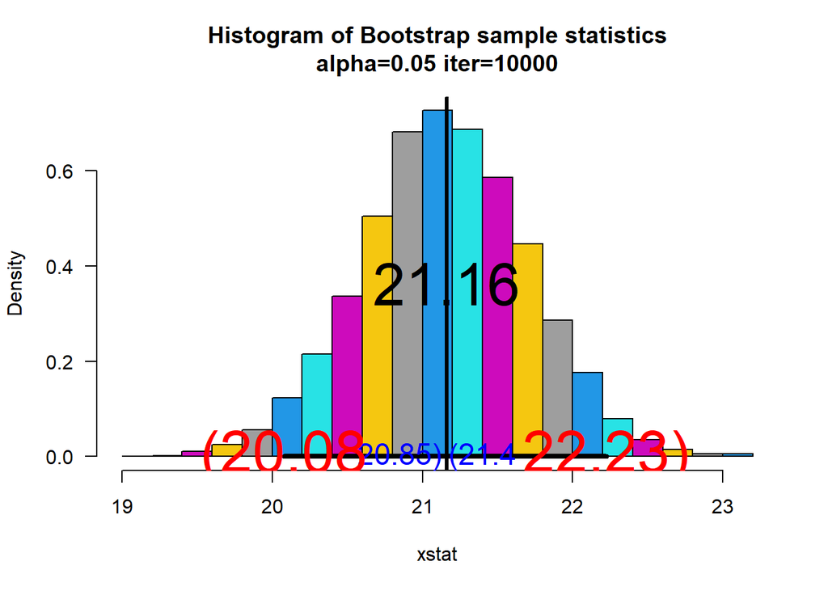

```
## $fun
## [1] "mean"
##
## $x
##  [1] 23.195 20.399 19.898 19.865 30.014 18.821 21.232 18.313 23.574 21.047
## [11] 21.535 21.336 17.695 18.497 14.274 14.664 22.593 18.963 25.515 25.019
## [21] 22.053 22.871 23.006 23.829 19.038 21.735 21.461 21.659 21.703 21.049
##
## $ci
##     2.5%    97.5%
## 20.07910 22.22545
```

```r
set.seed(35)
sam<-round(rnorm(30,mean=20,sd=3),3)
myboot(iter=10000,x=sam,fun="mean",alpha=0.05)
```